# Practice: Functions and if-else statements (part 2)

Stat 133

Author

Gaston Sanchez

**Learning Objectives**

- Create functions
- Use conditional statements in your functions
- Use `stop()` to stop execution of a function when applicable
- Use `warning()` to provide a warning message when applicable
- Include comments to document a function

In this module you will practice writing simple functions, and some basic examples to make sure that the functions work as expected. In addition to writing the functions, you should also practice documenting your functions. Writing this type of documentation should become second nature.

# 1 Toy Example

Here’s an example of a function `rect_area()` that computes the area of a rectangle. Notice the structure of the code below: the first lines correspond to **documentation comments** to indicate things such as the title, description, inputs, and outputs:

```r
# title: area of rectangle
# description: calculates the area of a rectangle
# inputs:
# - len length of the rectangle (numeric)
# - wid width of the rectangle (numeric)
# output: computed area
rect_area <- function(len = 1, wid = 1) {
  if (len < 0) {
    stop("len must be positive")
  }
  if (wid < 0) {
    stop("wid must be positive")
  }
  area = len * wid
  return(area)
}
```

Once the function has been created, we can test it with a couple of basic examples:

```r
# default
rect_area()
```

```
[1] 1
```

```r
# len=2, wid=3
rect_area(len = 2, wid = 3)
```

```
[1] 6
```

```r
# bad len
rect_area(len = -2, wid = 3)
```

```
Error in rect_area(len = -2, wid = 3): len must be positive
```

## 1.1 Roxygen Comments

**Pro Tip**

Roxygen comments are a special style for writing a function’s documentation.

From time to time, you will encounter code in R that use a special type of comments to define the documentation of a function: so-called **roxygen comments**. These comments follow a specific syntax, and they are commonly used when writing functions for an R package. Here’s an example:

```r
#' @title area of rectangle
#' @description calculates the area of a rectangle
#' @param len length of the rectangle (numeric)
#' @param wid width of the rectangle (numeric)
#' @return computed area
rect_area <- function(len = 1, wid = 1) {
  if (len < 0) {
    stop("len must be positive")
  }
  if (wid < 0) {
    stop("wid must be positive")
  }
  area <- len * wid
  return(area)
}
```

Once the function has been created, we can test it with a couple of basic examples:

```r
# default
rect_area()
```

```
[1] 1
```

```r
# len=2, wid=3
rect_area(len = 2, wid = 3)
```

```
[1] 6
```

```r
# bad len
rect_area(len = -2, wid = 3)
```

```
Error in rect_area(len = -2, wid = 3): len must be positive
```

```r
# bad wid
rect_area(len = 2, wid = -3)
```

```
Error in rect_area(len = 2, wid = -3): wid must be positive
```

# 2 Area of a circle

Consider a circle with `radius = 2`. The area of this circle can be computed in R as:

```r
# area of circle with radius 2
r = 2
area = pi * r^2
area
```

```
[1] 12.56637
```

## 2.1 Your Turn: `circle_area()` version 1

Write a function `circle_area()` that calculates the area of a circle.

- This function must take one argument `radius`.
- Give `radius` a default value of 1.
- Include comments to document your function! You can use regular comments, or if you feel brave enough try using roxygen comments.

**Show answer**

```r
#' @title area of circle
#' @description computes the area of a circle of given radius
#' @param radius numeric value
#' @return area
circle_area <- function(radius = 1) {
  pi * radius^2
}
```

Test your function with:

- no specified arguments: i.e. `circle_area()`;
- with `radius = 3`

```r
# default (radius 1)
circle_area()
```

```
[1] 3.141593
```

```r
# radius 3
circle_area(radius = 3)
```

```
[1] 28.27433
```

## 2.2 Your Turn: `circle_area()` version 2

Modify your `circle_area()` function in order to include a `stop()` statement. If `radius` is negative, then the function should stop with a meaningful error message, perhaps something like: `"radius cannot be negative"`.

**Show answer**

```r
#' @title area of circle
#' @description computes the area of a circle of given radius
#' @param radius numeric value
#' @return area
circle_area <- function(radius = 1) {
  if (radius < 0) {
    stop('radius cannot be negative')
  }
  pi * radius^2
}
```

Test your modified `circle_area()` with `radius = -2`; the function should return a stop message:

```r
# bad radius
circle_area(radius = -2)
```

```
Error in circle_area(radius = -2): radius cannot be negative
```

# 3 Area of a Cylinder

For a given cylinder of radius $r$ and height $h$ the surface area $A$ is given in the following diagram:

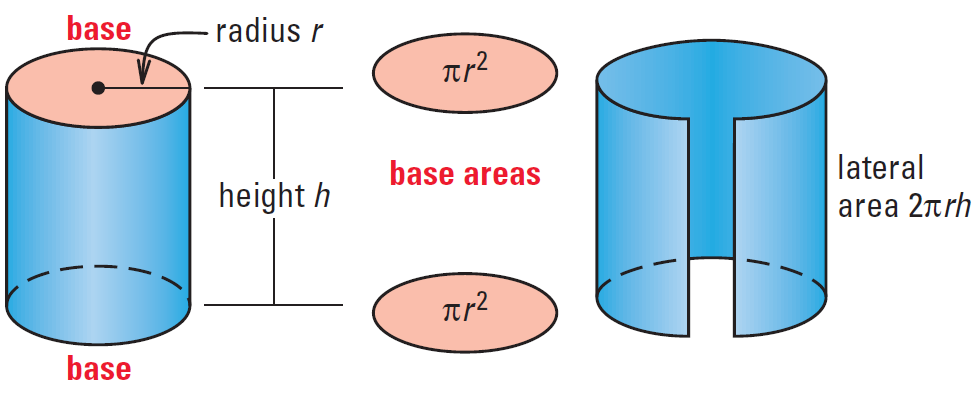

For example. Say you have a cylinder with radius = 2, and height = 3.

```r
# inputs
r = 2  # radius
h = 3  # height

# output: area of cylinder
2 * pi * r * h + 2 * pi * r^2
```

```
[1] 62.83185
```

Notice that the formula of the area of a cylinder includes the area of a circle: $\pi r^2$.

## 3.1 Your Turn: `cylinder_area()` function

Write a function `cylinder_area()`, that calls `circle_area()`, to compute the area of a cylinder.

- This function must take two arguments: `radius` and `height`,
- Give both arguments a default value of 1.
- The function should stop if any of `radius` or `height` are negative. Since you are calling `circle_area()`, you already have a `stop()` statement for a negative `radius`.
- Include documentation comments.

**Show answer**

```r
#' @title area of cylinder
#' @description computes the area of a cylinder
#' @param radius numeric value
#' @param height numeric value
#' @return area
cylinder_area <- function(radius = 1, height = 1) {
  if (height < 0) {
    stop('height must be positive')
  }
  lateral_area <- 2 * pi * radius * height
  base_areas <- 2 * circle_area(radius)
  lateral_area + base_areas
}
```

For instance:

```r
# default (radius 1, height 1)
cylinder_area()
```

```
[1] 12.56637
```

```r
# radius 2, height 3
cylinder_area(radius = 2, height = 3)
```

```
[1] 62.83185
```

These should return a meaningful error message:

```r
# bad radius
cylinder_area(radius = -2, height = 1)
```

```
Error in circle_area(radius): radius cannot be negative
```

```r
# bad height
cylinder_area(radius = 2, height = -1)
```

```
Error in cylinder_area(radius = 2, height = -1): height must be positive
```

# 4 Even and Odd Numbers

Any number that can be exactly divided by 2 is called an **even** number. R provides the modulo operator, `"%%"` that can be used to determine if a number is even or odd.

To be more precise, the modulo operator returns the remainder or signed remainder of a division.

For example, `4 %% 2` evaluates to 0, because 4 divided by 2 has a quotient of 2 and a remainder of 0:

```r
# 4 is exactly divisible by 2
4 %% 2
```

```
[1] 0
```

In contrast, `5 %% 2` would evaluate to 1, because 5 divided by 2 has a quotient of 2 and a remainder of 1

```r
# 5 is not exactly divisible by 2
5 %% 2
```

```
[1] 1
```

## 4.1 Your Turn: `is_even()` function

Write a function `is_even()` that determines whether a number is even (i.e. multiple of 2).

- If the input number is even, the output should be `TRUE`.
- If the input number is odd, the output should be `FALSE`.
- If the input is not a number, the output should be `NA`
- Include documentation comments.

**Show answer**

```r
#' @title is even
#' @description test if a given number is even
#' @param x numeric value
#' @return whether the input is even
is_even <- function(x) {
  if (is.numeric(x)) {
    return(x %% 2 == 0)
  } else {
    return(NA)
  }
}
```

Test your function:

```r
# even number
is_even(10)
```

```
[1] TRUE
```

```r
# odd number
is_even(33)
```

```
[1] FALSE
```

```r
# not a number
is_even('a')
```

```
[1] NA
```

## 4.2 Your Turn: `is_odd()` function

Use your function `is_even()` to write a function `is_odd()` that determines if a number is odd (i.e. not a multiple of 2).

- If a number is odd, the output should be `TRUE`;
- If a number is even the output should be `FALSE`;
- If the input is not a number the output should be `NA`
- Include documentation comments.

**Show answer**

```r
#' @title is odd
#' @description test if a given number is odd
#' @param x numeric value
#' @return whether the input is odd
is_odd <- function(x) {
  !is_even(x)
}
```

Test `is_odd()` with the following cases:

```r
# odd number
is_odd(1)
```

```
[1] TRUE
```

```r
# even number
is_odd(4)
```

```
[1] FALSE
```

```r
# not a number
is_odd('a')
```

```
[1] NA
```